# Is buying “green” (environmentally-friendly) products driven by status motives?

*N* removed NAs: 4

*N* removed <18: 16

**Correct typo age:** 21

*N* total clean: 148

| Group | *N* | *M*<sub>age</sub> | % green |
| --- | --- | --- | --- |
| Control | 70 | 21.11 | 37.62 |
| Experim | 78 | 21.31 | 50.00 |

| Gender | *N* | *M*<sub>age</sub> | % green |
| --- | --- | --- | --- |
| Female | 73 | 21.00 | 45.21 |
| Male | 52 | 21.63 | 44.87 |
| Other | 23 | 20.96 | 39.13 |

**Main analysis results**

**car:**  
χ<sup>2</sup>(1) = 4.4, *p* = .036

**cleaner:**  
χ<sup>2</sup>(1) = 0.37, *p* = .543

**dishwasher:**  
χ<sup>2</sup>(1) = 1.81, *p* = .179

[interactive chart not shown]

[figure not shown]

[interactive chart not shown]

# **Is buying “green” (environmentally-friendly) products driven by status motives?**

Analysing Data Coursework Report, Spring 2020, CN: 218054

# Methods

## Design

The research carried out on hybrid cars as social signals of status can be linked to the growing consumption of luxury yet sustainable brands (Griskevicius et al., 2007). My study is a replication of the study conducted by Griskevicius et. al (2010) in which all participants partook in a between-subjects design either under a status or a control motivation. Those in the experimental condition made choices after being exposed to status motive primes, whereas the control condition had limited priming before making their product choices. In the control condition, wherein participants were less primed, they imagined that they would purchase the more luxury, less eco-friendly car (Grivkevicius et al., 2010). In order to elicit these status motives, participants read a short story of approximately 700 words that Tyber et al. (2009) used in previous research. The conditions are the key independent variables that are operationalised into two similarly constructed stories. The stories are similar in happenstance, however under the experimental condition the events that occur are seen to stimulate status signalling and evoke altrusitic tendencies. The control condition lacks this. The dependent variables were the choices made and the frequencies amongst the particpants. After priming, the three types of product - namely; *car*, *cleaner*, and *dishwasher* products - were presented in random order.

Futhermore, I carried Pearson’s chi-squared test for my statistical analysis due to my data being *categorical*, but also in order to observe how likely the distribution of the data is due to chance (Ling, 2008). In other words, this “goodness of fit” statistic is used to determine whether we should accept our own hypothesis rather than the *null hypothesis* by showing the likelihood of our variables being dependent. An alpha of 0.05 was used as the cutoff for significance. Therefore, if the *p*-value is >0.05, the null hypothesis can be rejected as there is no difference between the means, thus concluding that a significant difference does exist.

**Hypothesis**

After reading a series of evocative stories including status motive primes, a choice of a more respected yet less luxurious “green” product will be made when deciding which product one would most likely purchase.

# Results

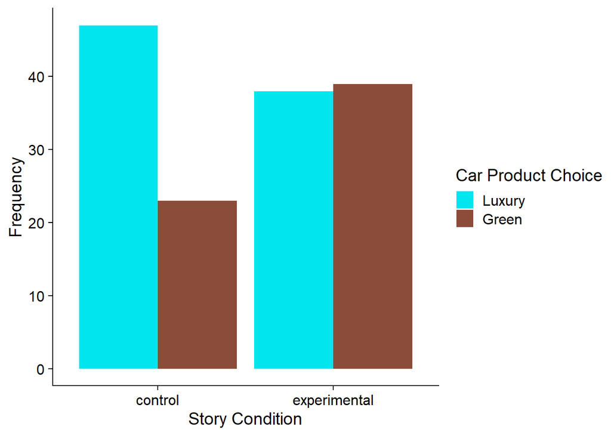

**Figure 1. The choice of a luxury or green car in each condition**

**Statistical Analysis**

Car Contingency Table

|  | Luxury | Green |
| --- | --- | --- |
| Control | 47 | 23 |
| Experimental | 38 | 39 |

Car Expected Frequencies

|  | Luxury | Green |
| --- | --- | --- |
| Control | 40.48 | 29.52 |
| Experimental | 44.52 | 32.48 |

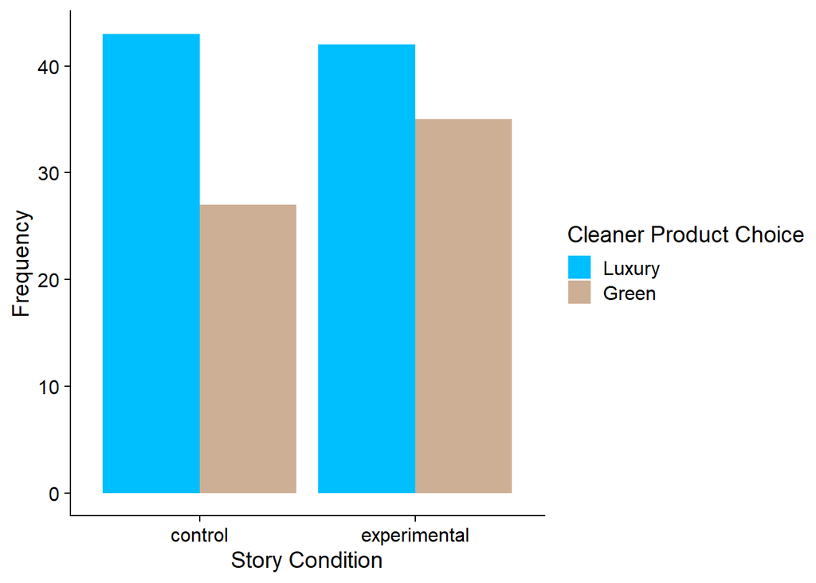

**Figure 2. The choice of a luxury or green cleaner in each condition**